# pisa_eda

Ian Drea Riley

03/13/2015

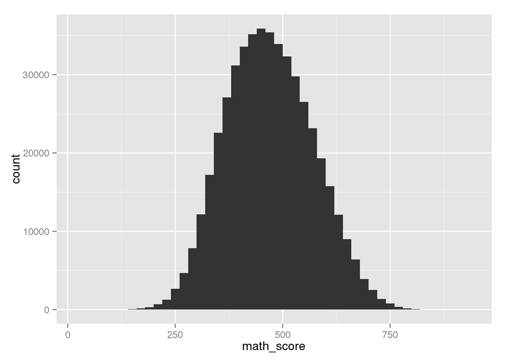

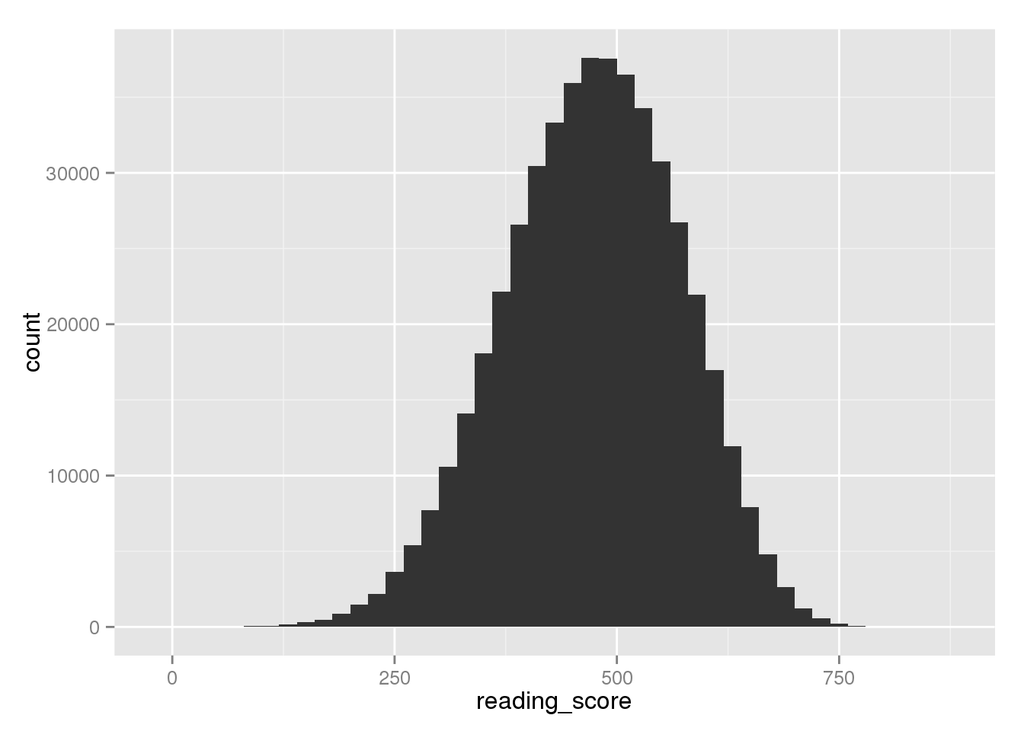

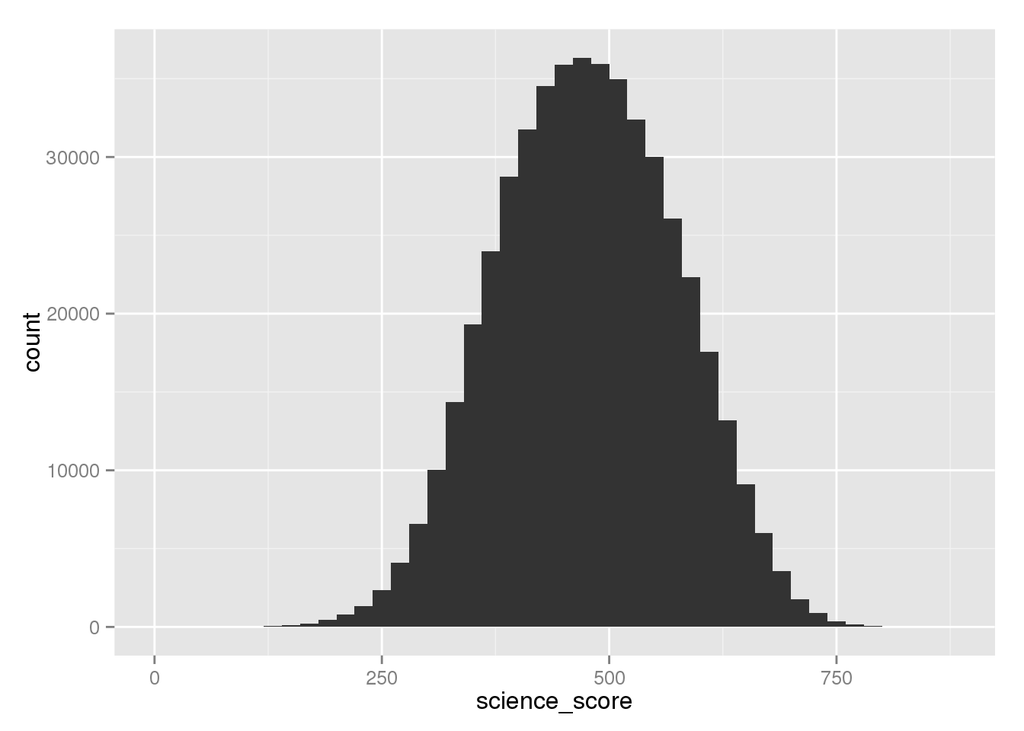

Distributions for scores are normal

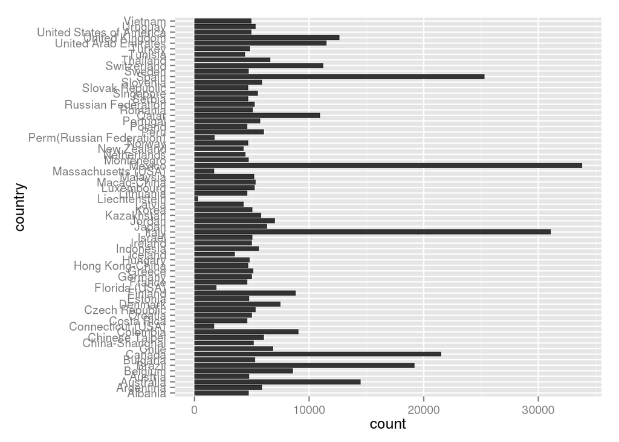

Mass., Conn., FLA all listed as separate from United States. These should be aggregated.

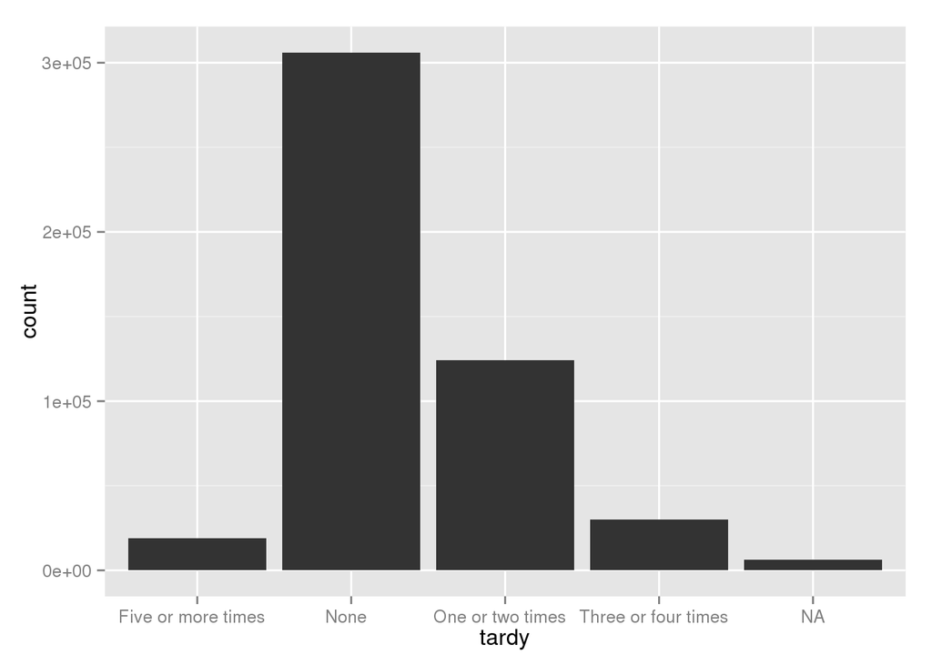

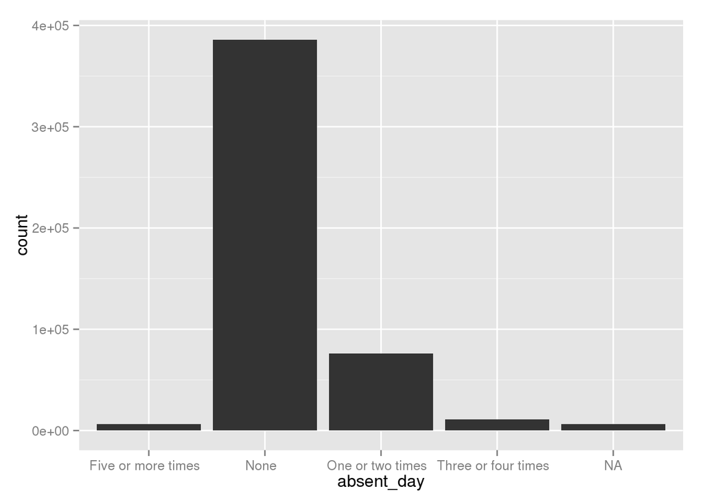

```
## stat_bin: binwidth defaulted to range/30. Use 'binwidth = x' to adjust this.
```

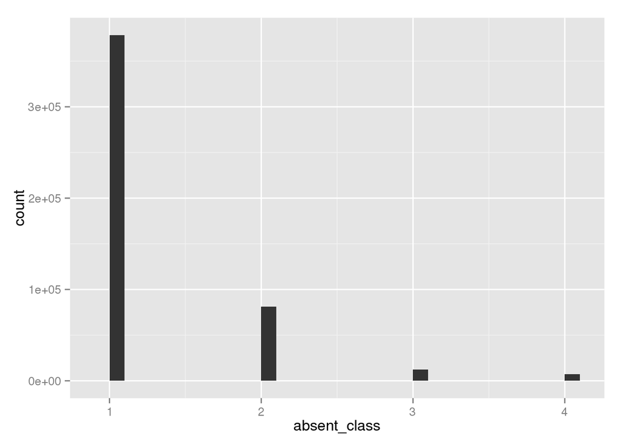

The absent_class variable is confusing - this seems to say that every student missed at least one class, which seems wrong.

```
## stat_bin: binwidth defaulted to range/30. Use 'binwidth = x' to adjust this.
```

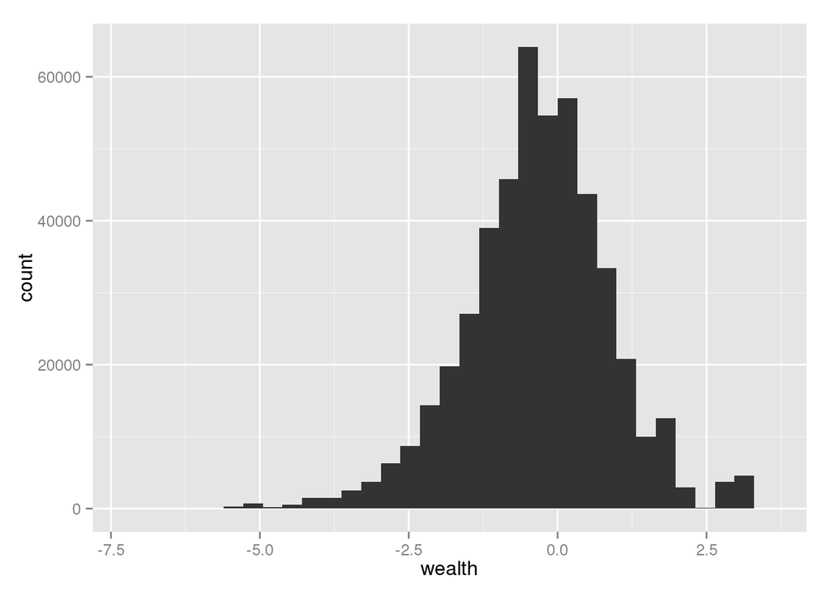

A strangely normal distribution for wealth. I’d expect it to be more right skewed. I’m assuming this is a logarithmic scale.

```
## stat_bin: binwidth defaulted to range/30. Use 'binwidth = x' to adjust this.
```

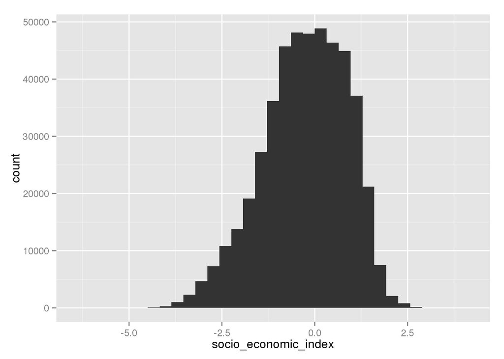

Normalish, left skew. Range similar to wealth

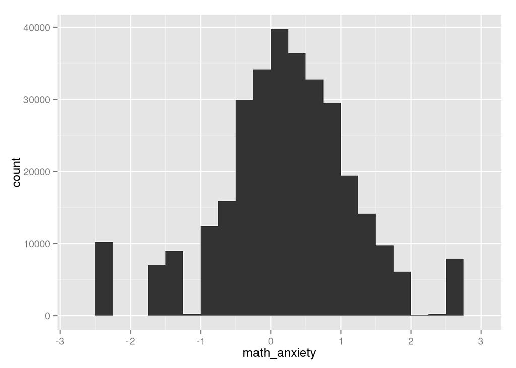

```
##    Min. 1st Qu.  Median    Mean 3rd Qu.    Max.    NA's
##   -2.37   -0.47    0.06    0.15    0.79    2.55  170726
```

Normal distribution with some hiccups.

```
## stat_bin: binwidth defaulted to range/30. Use 'binwidth = x' to adjust this.
```

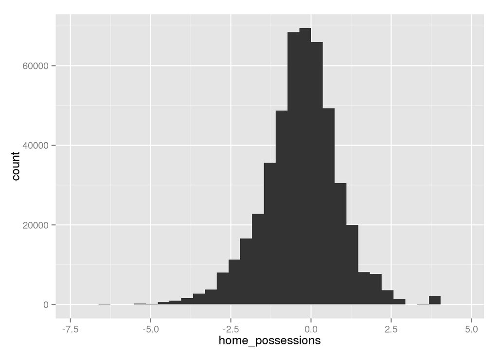

Curious about scale used here. distributino normal with slight left skew

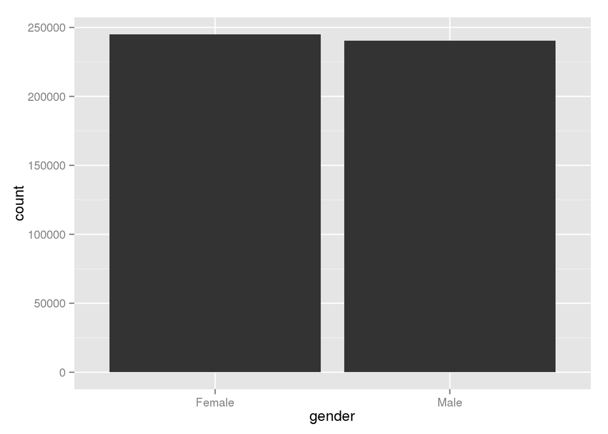

Roughly even split. Slightly more women than men

```
## stat_bin: binwidth defaulted to range/30. Use 'binwidth = x' to adjust this.
```

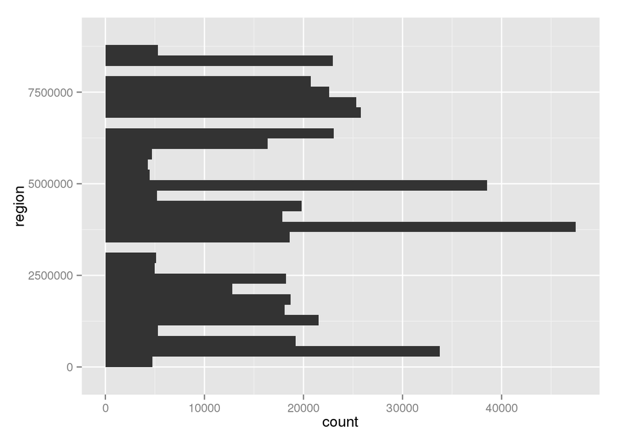

Will have to figure out how to translate these numbers into meaningful regions

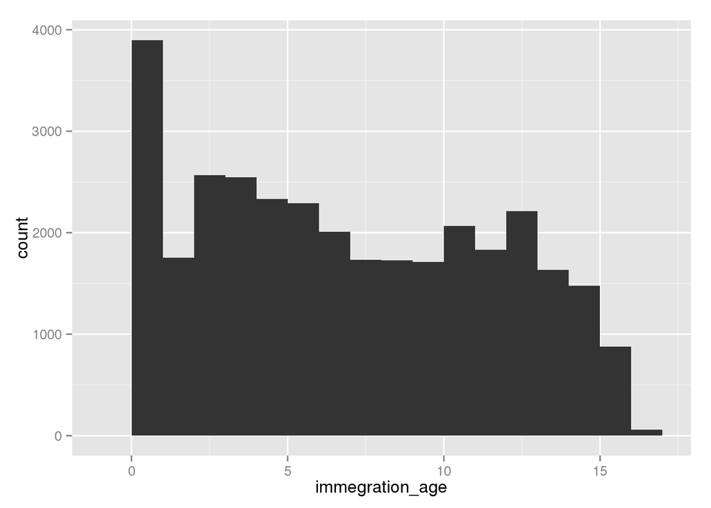

Surprising that so few values are 0 - this would seem to suggest that the bulk of students are immigrants, which seems unlikely.

```
##    Min. 1st Qu.  Median    Mean 3rd Qu.    Max.    NA's
##     0.0     2.0     6.0     6.5    10.0    16.0  452762
```

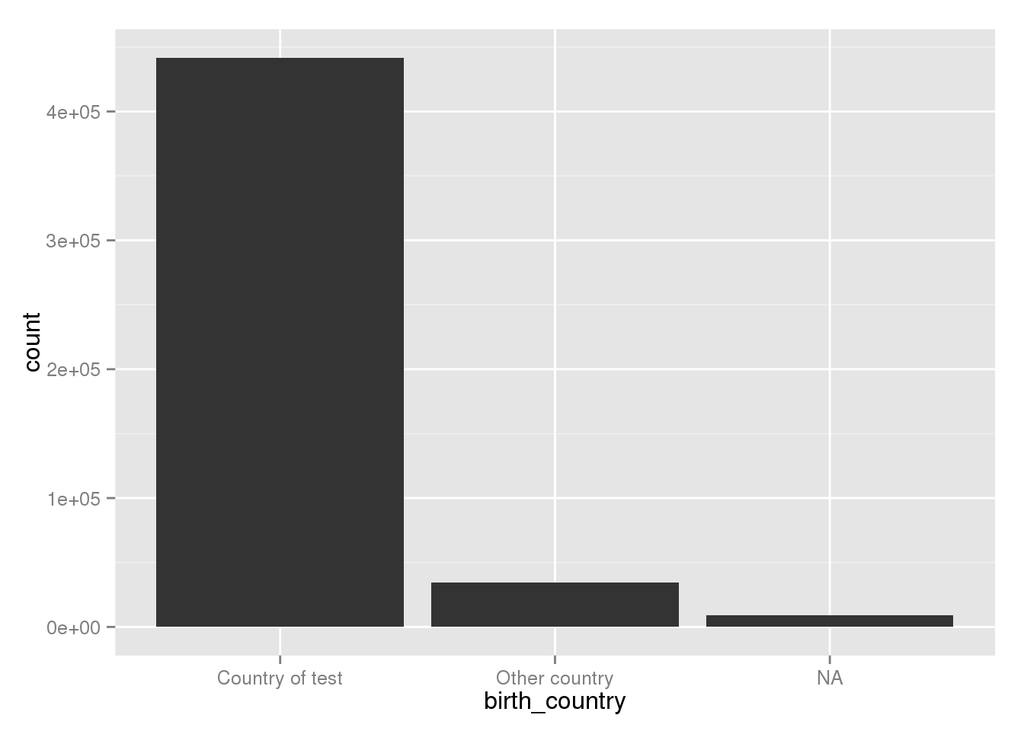

```
## Country of test   Other country            NA's
##          441726           34637            9127
```

A good, low number of NAs (~1.9%). This may help make a case for imputing values for the immigration age variable.

## UNIVARIATE ANALYSIS

Many of the distributions are normal, which is nice. Consider a strategy for imputing values across the immigration_age variable. Also, is the region code actually necessary? It may not be unless I’m going to compare regions, which may be very difficult if they’re not in the US. Check whether the States that have a different country value than the United States of America (Florida, Connecticut and Massachusetts) are already included in the US value and can be dropped, or if they should be aggregated into the US.

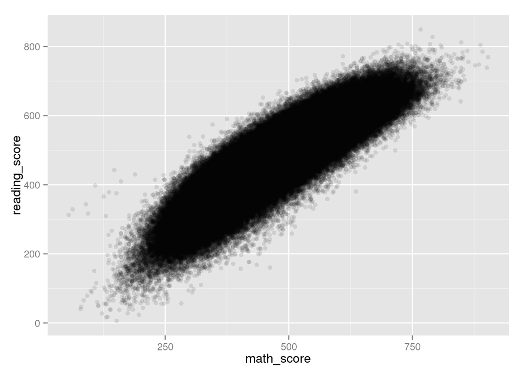

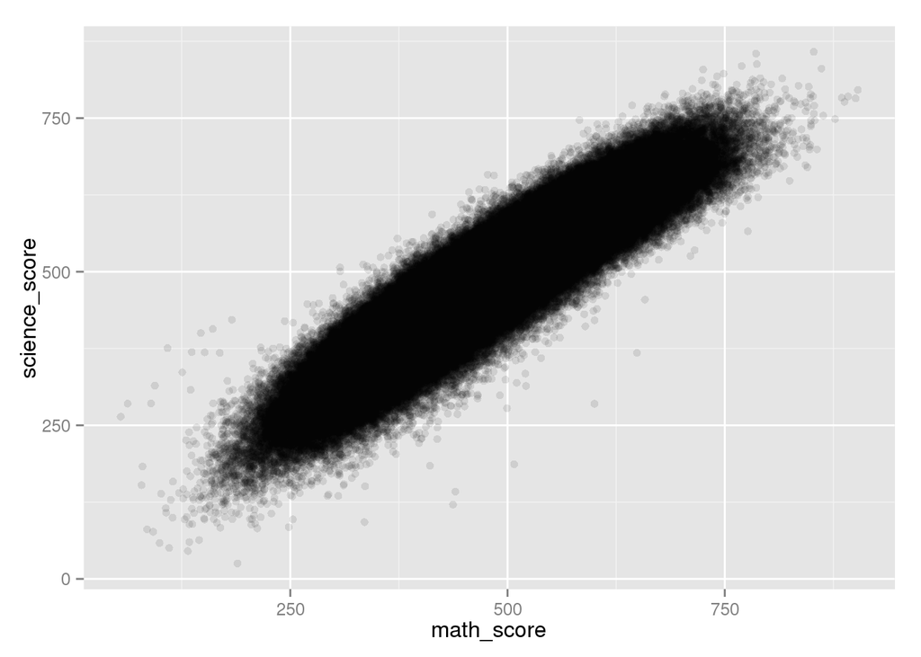

The scores from the tests have strong linear correlation. The variance for science scores given a math score appears smaller than the variance for reading scores given a math score. Given that Science is more math-based, this is not surprising.

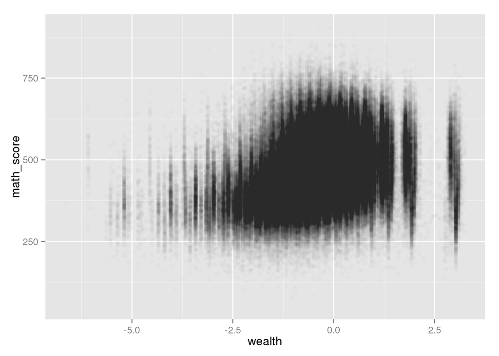

```
##
##  Pearson's product-moment correlation
##
## data:  wealth and math_score
## t = 194.6612, df = 479595, p-value < 2.2e-16
## alternative hypothesis: true correlation is not equal to 0
## 95 percent confidence interval:
##  0.2679759 0.2732218
## sample estimates:
##       cor
## 0.2706009
```

Interestingly, there does not seem to be a very strong correlation between wealth and math scores.

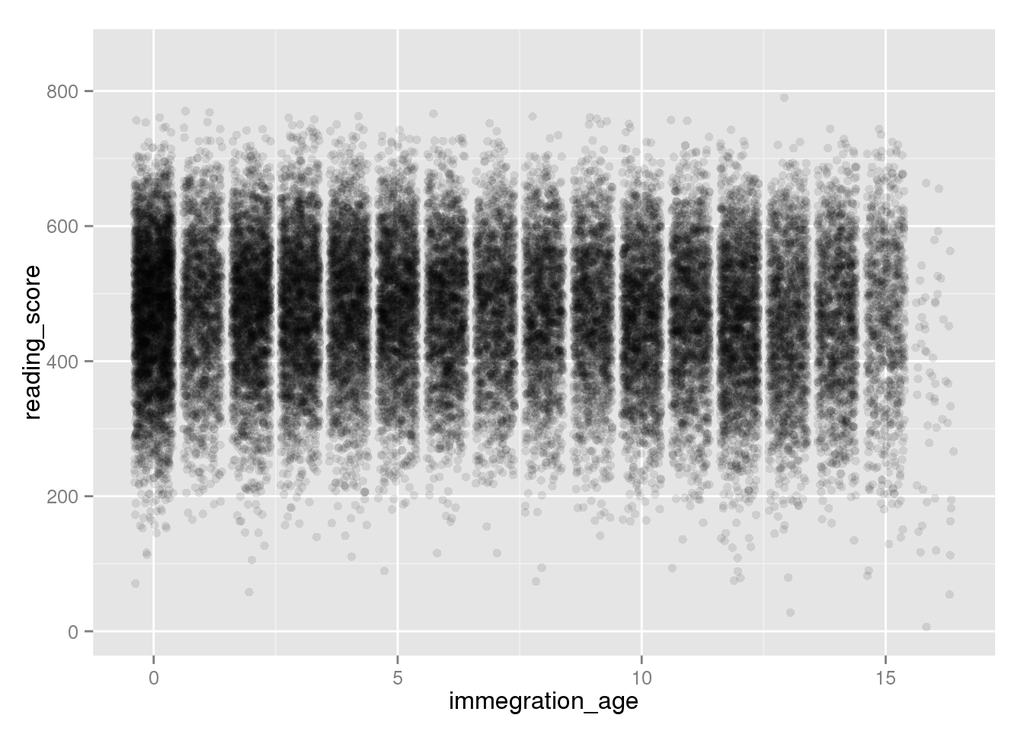

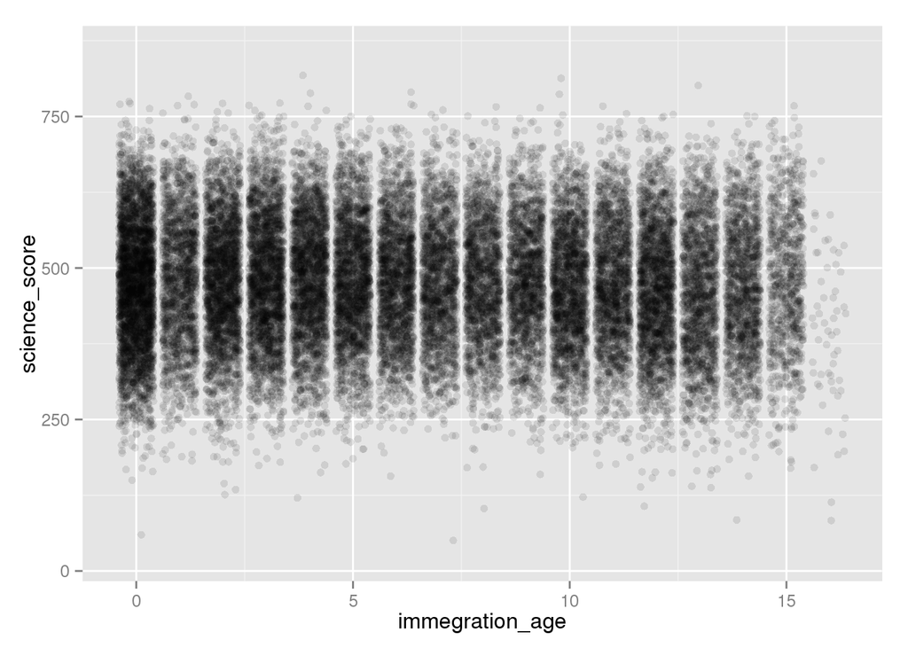

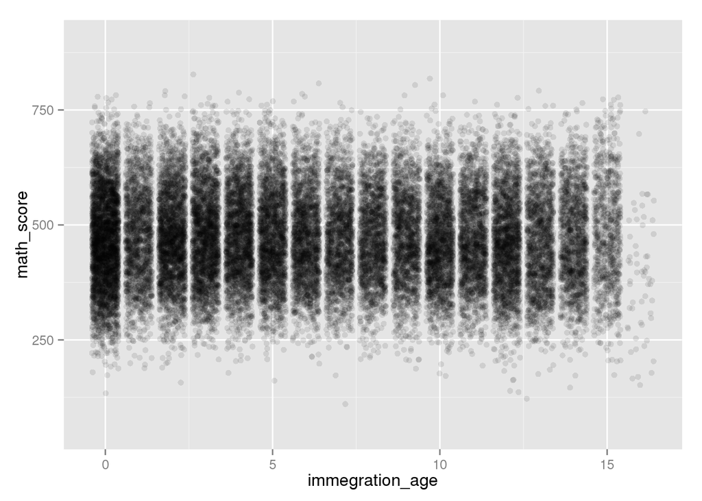

```
##
##  Pearson's product-moment correlation
##
## data:  immegration_age and reading_score
## t = -10.0193, df = 32726, p-value < 2.2e-16
## alternative hypothesis: true correlation is not equal to 0
## 95 percent confidence interval:
##  -0.06609480 -0.04449293
## sample estimates:
##         cor
## -0.05530034
```

```
##
##  Pearson's product-moment correlation
##
## data:  immegration_age and math_score
## t = -4.0344, df = 32726, p-value = 5.488e-05
## alternative hypothesis: true correlation is not equal to 0
## 95 percent confidence interval:
##  -0.03312166 -0.01146431
## sample estimates:
##        cor
## -0.0222956
```

```
##
##  Pearson's product-moment correlation
##
## data:  immegration_age and science_score
## t = -8.0204, df = 32726, p-value = 1.089e-15
## alternative hypothesis: true correlation is not equal to 0
## 95 percent confidence interval:
##  -0.05509939 -0.03347378
## sample estimates:
##         cor
## -0.04429177
```

Immigration age seems to have no affect on scores

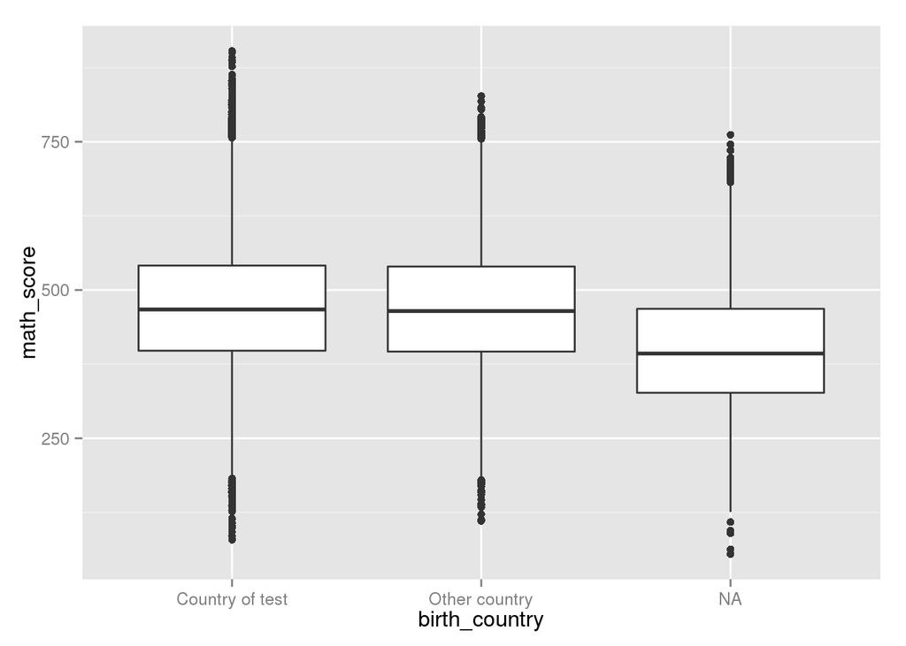

Country of birth appears to have no affect on math score, however the median score for students who did not respond (NAs) is significantly lower than for students who did. There is some non-response bias at work.

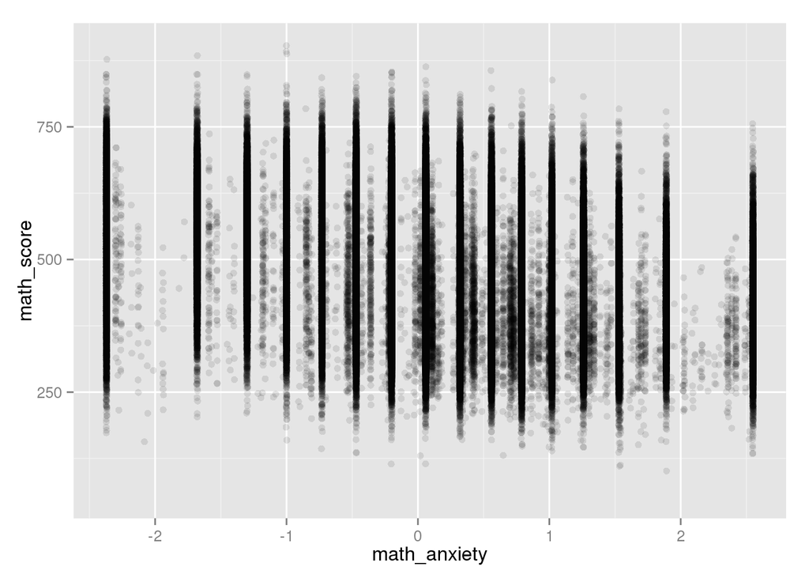

```
##
##  Pearson's product-moment correlation
##
## data:  math_anxiety and math_score
## t = -225.3901, df = 314762, p-value < 2.2e-16
## alternative hypothesis: true correlation is not equal to 0
## 95 percent confidence interval:
##  -0.3757853 -0.3697693
## sample estimates:
##        cor
## -0.3727812
```

While the graph is certainly ugly, there is some correlation between math anxiety and math score

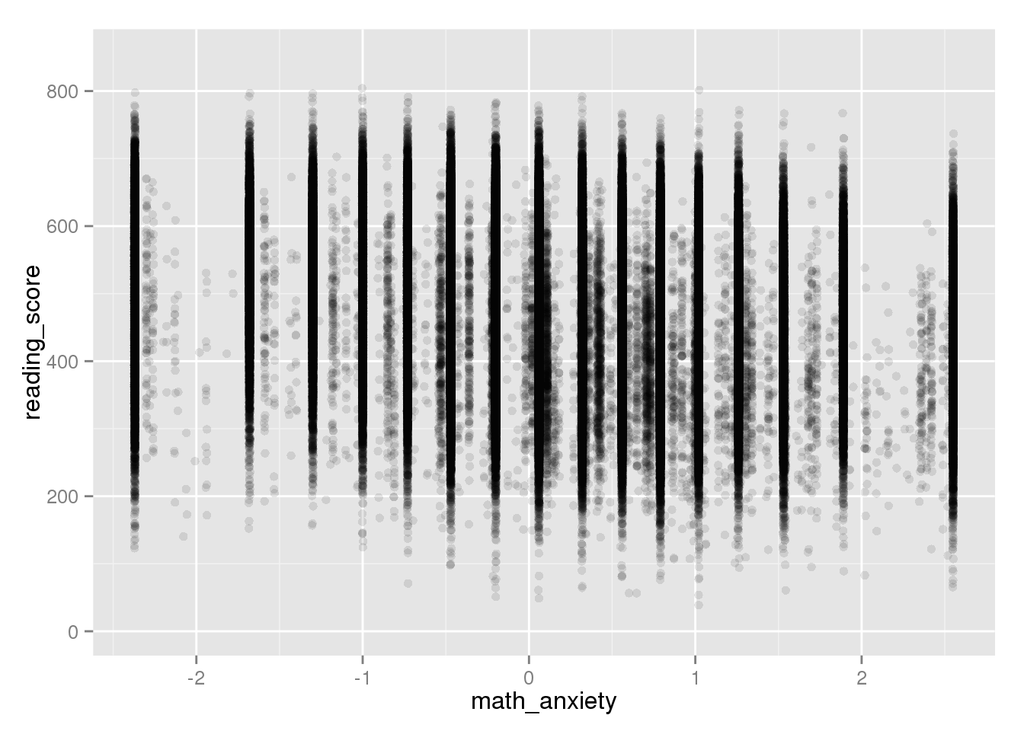

```
##
##  Pearson's product-moment correlation
##
## data:  math_anxiety and reading_score
## t = -148.4733, df = 314762, p-value < 2.2e-16
## alternative hypothesis: true correlation is not equal to 0
## 95 percent confidence interval:
##  -0.2590959 -0.2525663
## sample estimates:
##       cor
## -0.255834
```

There is also some correlation between math anxiety and reading score, however, it is less than with math score.

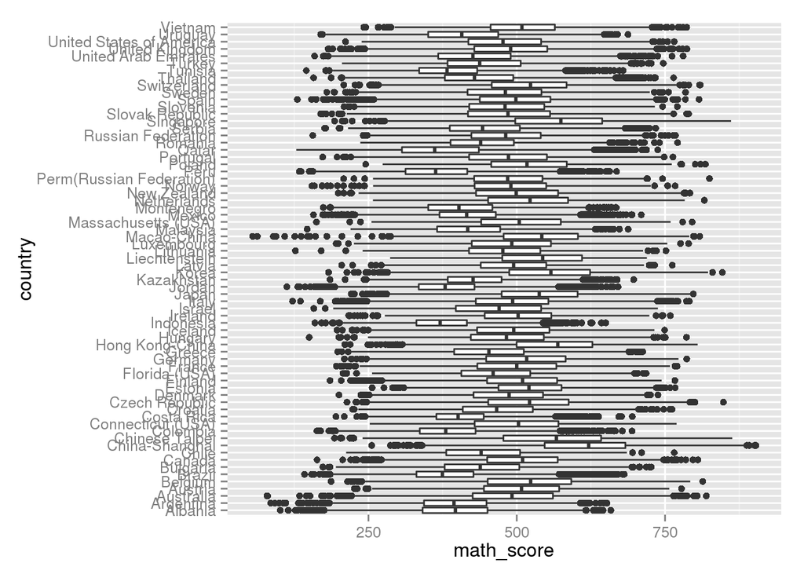

Notable difference amongst countries

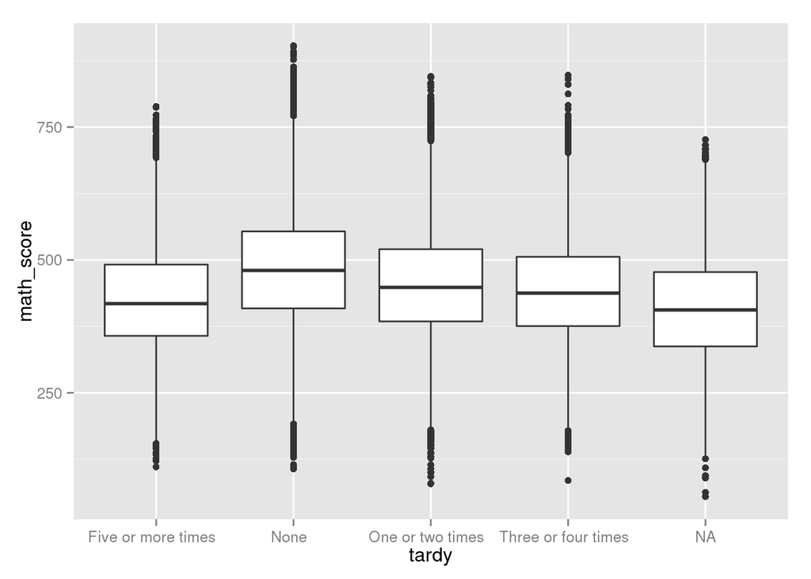

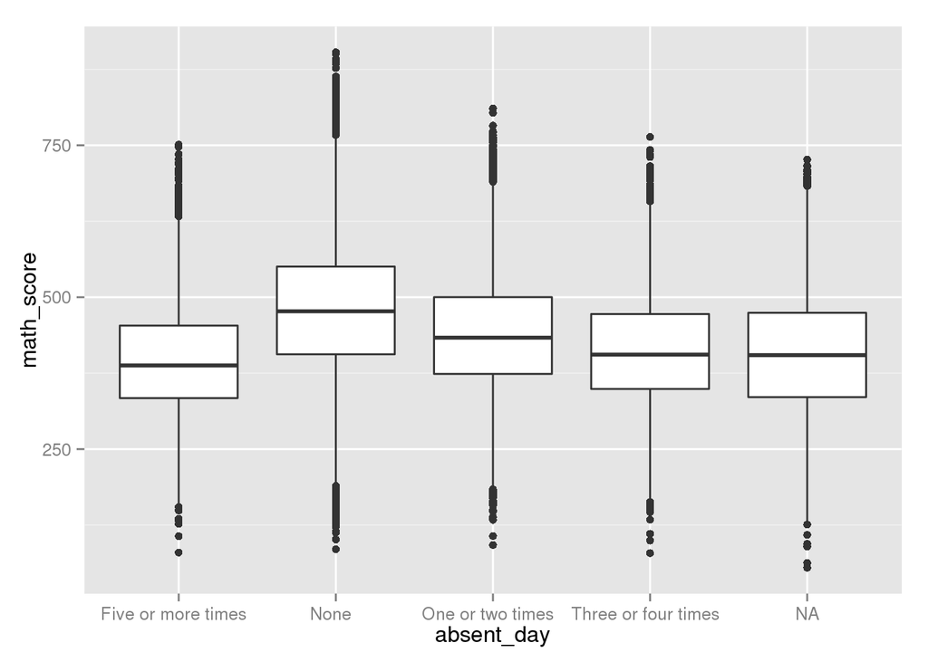

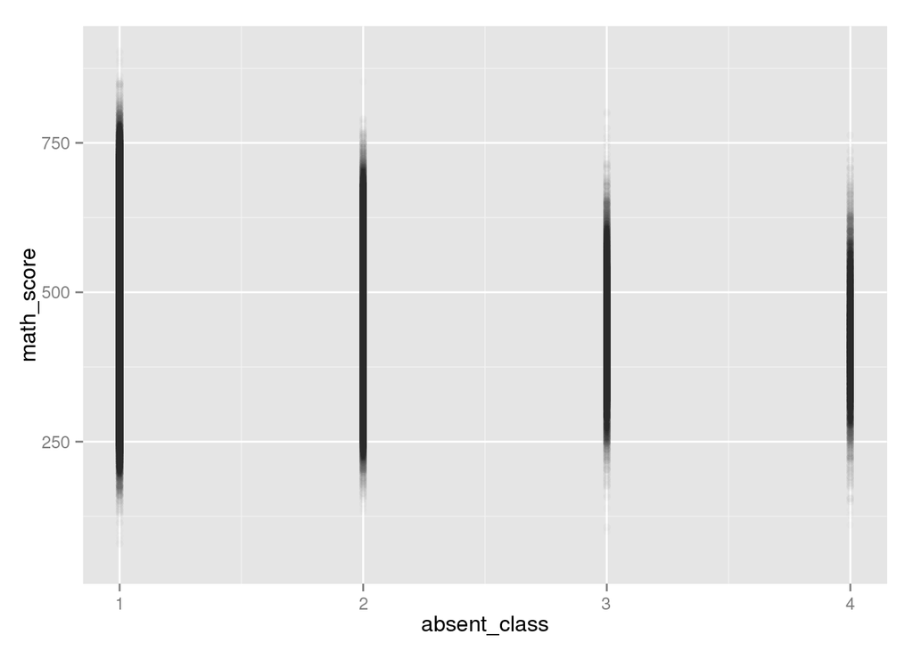

Lateness does affect classes. Also note non-response bias: NA box is similar to Five or more times. The absent_class variable needs to be changed to an ordinal variable.

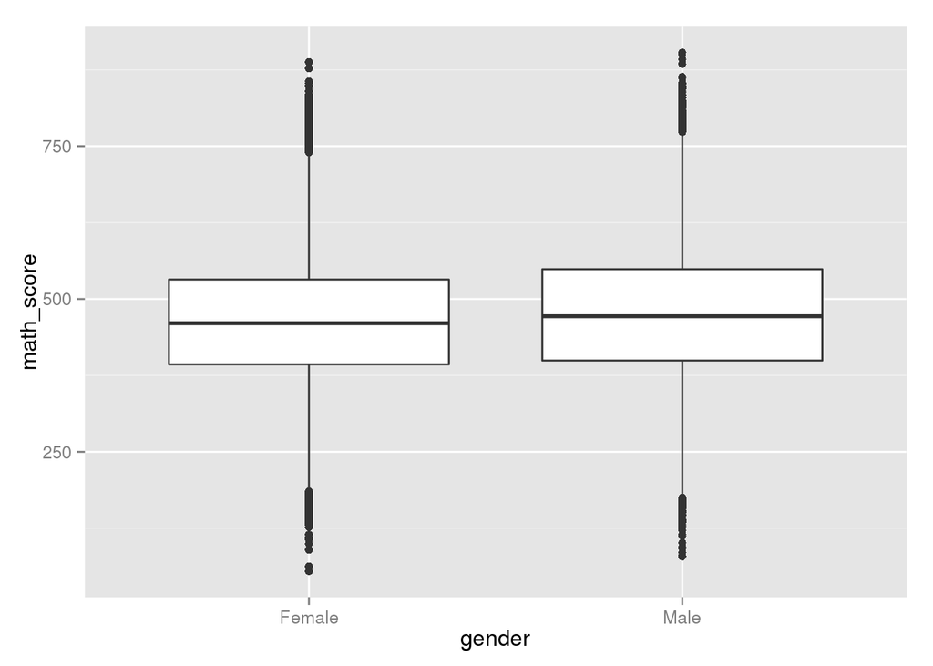

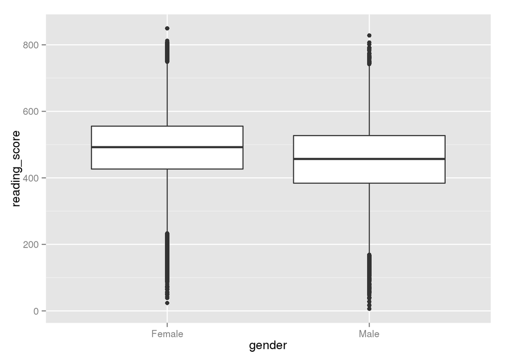

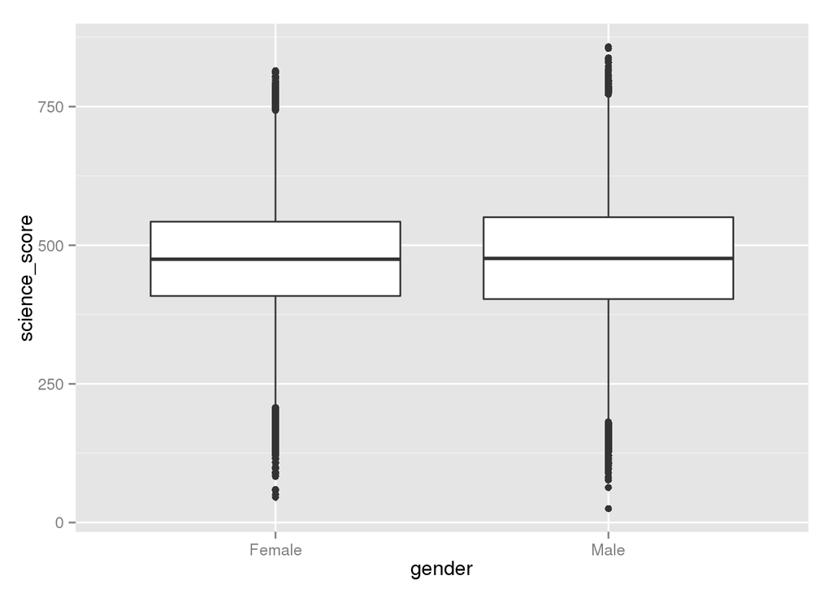

Interestingly, women do better with reading comprehension, men do slightly better with math, and they are about the same with science.

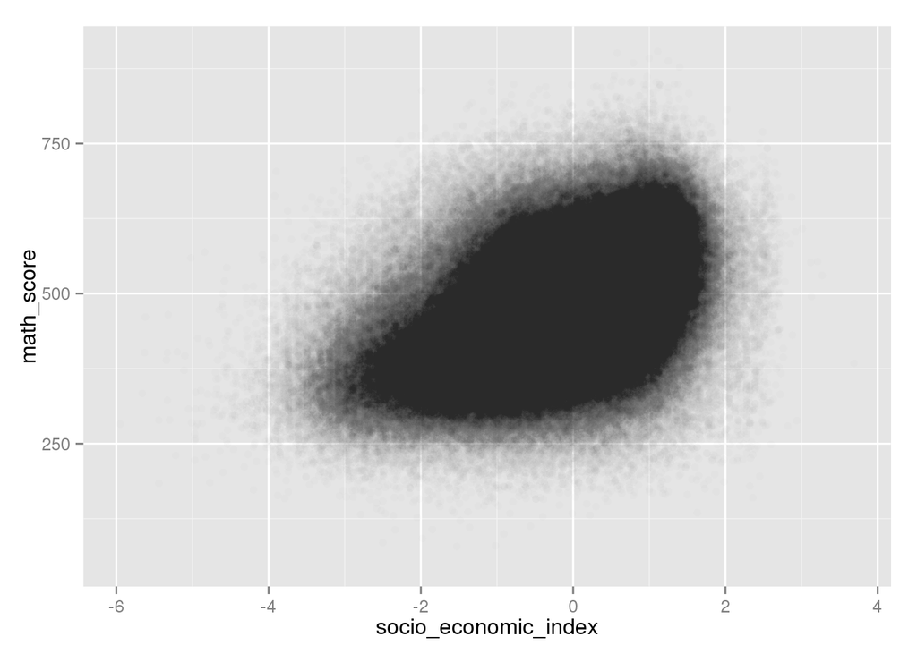